# Ensayo Regresión Lineal

### **Carlos Ricardo Collazos García**

#### *Diplomado Machine Learning*

#### *Universidad Nacional de Colombia*

[Dataset](https://www.kaggle.com/budincsevity/szeged-weather)

Escriba un ensayo sobre el tema Regresión Lineal, en un cuaderno de Jupyter.

Debe incluir:

1. Introducción.
2. Breve historia.
3. El planteamiento del algortimo.
4. Desarrollar un ejemplo de regresión lineal, con datos reales.
5. Conclusiones.

El cuaderno debe incluir: títulos, enlaces (por ejemplo a Wikipedia), imágenes locales, imágenes de internet, el plantemiento matemático del problema, y su implementación en Ptyhon. Incluya gŕaficas hechas en Matplotlib. Además debe usar como mínimo: Numpy (para manejo de arreglos) y Pandas para lectura de datos.

Esta tarea es para entregar en su github personal, en cual colocará el cuaderno de Jupyer Lab y la renderización con nbview y html.

## Introducción

[figure not shown]

Szeged, *a napfény városa*, la ciudad de la luz del sol en Hungría. Es la tercera ciudad más poblada del país y recibe el título de *ciudad de la luz del sol* porque es la ciudad húngara con mayor cantidad de horas de sol al año. Conocida por su producción de páprika, por la universidad y por la inundación que casi la borra por completo hace más de un siglo, es además la ciudad en la que viví por 4 años.

Por otro lado, la [regresión lineal](https://en.wikipedia.org/wiki/Linear_regression) es una herramienta de modelamiento de una variable escalar que es función de uno o más valores y que resulta útil para predicción de fenómenos con comportamiento lineal. La intención principal de este ensayo es presentar un modelo lineal básico, en este caso, de información del clima de Szeged entre los años 2006 y 2016, disponible en la plataforma Kaggle ([link](https://www.kaggle.com/budincsevity/szeged-weather)).

Las preguntas que trataremos de resolver en este ensayo son:

- ¿Existe alguna relación entre humedad y temperatura?
- ¿Es posible predecir la temperatura aparente en la ciudad a partir de la humedad?

## Antecedentes e Historia

Szeged ha sido partícipe de eventos históricos de los últimos 2 siglos, incluyendo el origen de algunas de las revoluciones húngaras (1848 y 1956) y de catástrofes como su famosa inundación de 1879. El clima de la ciudad siempre ha sido de gran interés, al punto de darle su apodo de *ciudad de la luz del sol* por recibir la mayor cantidad de luz solar durante el año en el territorio húngaro.

Llegué a esta ciudad a estudiar ciencias de la computación en 2015 y regresé a Colombia después de haber trabajado y estudiado allí por un total de 4 años. Para lo que compete a este ensayo, solo es necesario agregar que puedo dar fe de lo que diga aquí al respecto de la ciudad y sus características, así como de las fotos que incluyo.

[figure not shown]

## La Regresión Lineal

El primer registro de la regresión lineal se atribuye a Legendre en 1805, aunque también hayan aportado a ella otros matemáticos, por ejemplo, Gauss. Su propósito principal es determinar los pesos de la siguiente ecuación:

$$y = w_1*x + w_0$$

Si el modelo pretende modelar más de una variable de entrada, la ecuación requerirá $n+1$ pesos $w$ en donde $n$ es la cantidad de variables y el peso adicional se refiere al offset, asumiendo que el modelo no provendrá de datos centrados.

## Desarrollo del problema

Las preguntas que trataremos de resolver en este ensayo son:

- ¿Existe alguna relación entre humedad y temperatura?
- ¿Es posible predecir la temperatura aparente en la ciudad a partir de la humedad?

Is there a relationship between humidity and temperature? What about between humidity and apparent temperature? Can you predict the apparent temperature given the humidity?

```python
import numpy as np
import pandas as pd
import  matplotlib.pyplot as plt
import seaborn as sns

from pprint import pprint

%matplotlib inline
```

```python
# CONFIG
RANDOM_SEED = 42
PLOT_SAMPLE_SIZE = 10000
```

```python
df = pd.read_csv("weatherHistory.csv")
```

```python
pprint(df.columns.to_list())
```

```
['Formatted Date',
 'Summary',
 'Precip Type',
 'Temperature (C)',
 'Apparent Temperature (C)',
 'Humidity',
 'Wind Speed (km/h)',
 'Wind Bearing (degrees)',
 'Visibility (km)',
 'Loud Cover',
 'Pressure (millibars)',
 'Daily Summary']
```

```python
df.head()
```

|  | Formatted Date | Summary | Precip Type | Temperature (C) | Apparent Temperature (C) | Humidity | Wind Speed (km/h) | Wind Bearing (degrees) | Visibility (km) | Loud Cover | Pressure (millibars) | Daily Summary |
| --- | --- | --- | --- | --- | --- | --- | --- | --- | --- | --- | --- | --- |
| 0 | 2006-04-01 00:00:00.000 +0200 | Partly Cloudy | rain | 9.472222 | 7.388889 | 0.89 | 14.1197 | 251.0 | 15.8263 | 0.0 | 1015.13 | Partly cloudy throughout the day. |
| 1 | 2006-04-01 01:00:00.000 +0200 | Partly Cloudy | rain | 9.355556 | 7.227778 | 0.86 | 14.2646 | 259.0 | 15.8263 | 0.0 | 1015.63 | Partly cloudy throughout the day. |
| 2 | 2006-04-01 02:00:00.000 +0200 | Mostly Cloudy | rain | 9.377778 | 9.377778 | 0.89 | 3.9284 | 204.0 | 14.9569 | 0.0 | 1015.94 | Partly cloudy throughout the day. |
| 3 | 2006-04-01 03:00:00.000 +0200 | Partly Cloudy | rain | 8.288889 | 5.944444 | 0.83 | 14.1036 | 269.0 | 15.8263 | 0.0 | 1016.41 | Partly cloudy throughout the day. |
| 4 | 2006-04-01 04:00:00.000 +0200 | Mostly Cloudy | rain | 8.755556 | 6.977778 | 0.83 | 11.0446 | 259.0 | 15.8263 | 0.0 | 1016.51 | Partly cloudy throughout the day. |

```python
print("Cantidad de registros:\t{0}".format(len(df)))
```

```
Cantidad de registros:	96453
```

Para resolver la primera pregunta, comencemos por hacer un gráfico de dispersión de la temperatura y la humedad.

```python
df_plot = df.sample(n=PLOT_SAMPLE_SIZE, random_state=RANDOM_SEED)
```

```
[]
```

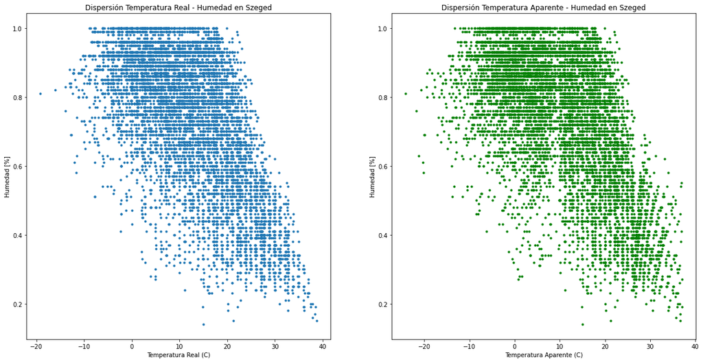

```python
fig, ax = plt.subplots(1,2)
fig.set_size_inches(20,10)

# Gráfico Temperatura Real
ax[0].set_title("Dispersión Temperatura Real - Humedad en Szeged")
ax[0].set_xlabel("Temperatura Real (C)")
ax[0].set_ylabel("Humedad [%]")
ax[0].scatter(df_plot["Temperature (C)"], df_plot["Humidity"], marker='.')

# Gráfico Temperatura Aparente
ax[1].set_title("Dispersión Temperatura Aparente - Humedad en Szeged")
ax[1].set_xlabel("Temperatura Aparente (C)")
ax[1].set_ylabel("Humedad [%]")
ax[1].scatter(df_plot["Apparent Temperature (C)"], df_plot["Humidity"], color="green", marker='.')

plt.plot()
```

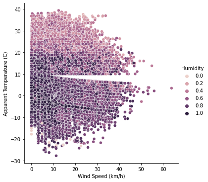

```python
plt.figure(figsize=(15, 15))
sns.relplot(hue='Humidity', y='Apparent Temperature (C)', x='Wind Speed (km/h)', data=df)
```

Sabemos previamente que la temperatura aparente depende de la temperatura actual, la humedad y la velocidad del viento, así que graficaremos la diferencia entre la temperatura aparente y la temperatura real versus la velocidad del viento y la humedad.

```python
df["Diff Temp"] = df["Apparent Temperature (C)"] - df["Temperature (C)"]
```

```
[]
```

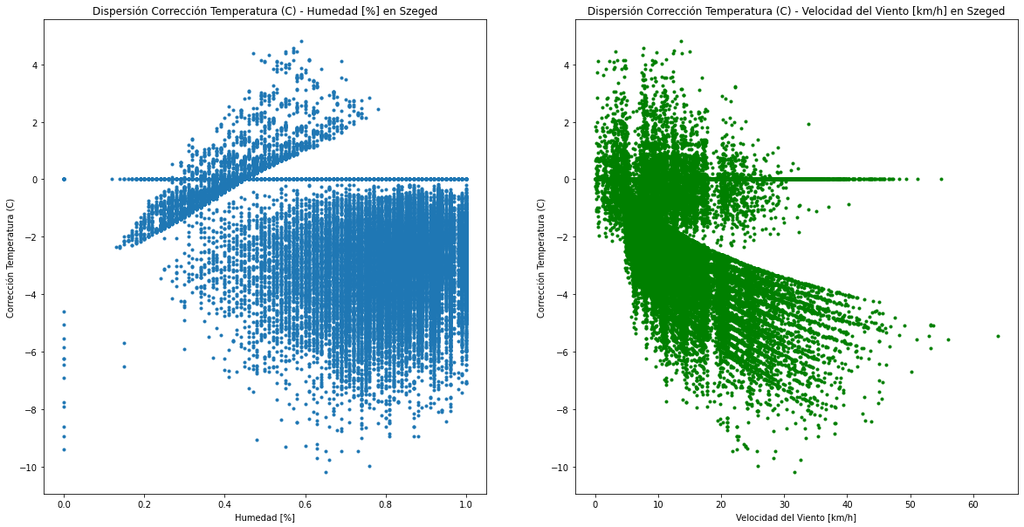

```python
fig, ax = plt.subplots(1,2)
fig.set_size_inches(20,10)

# Gráfico Temperatura Real
ax[0].set_title("Dispersión Corrección Temperatura (C) - Humedad [%] en Szeged")
ax[0].set_xlabel("Humedad [%]")
ax[0].set_ylabel("Corrección Temperatura (C)")
ax[0].scatter(df["Humidity"], df["Diff Temp"], marker='.')

# Gráfico Temperatura Aparente
ax[1].set_title("Dispersión Corrección Temperatura (C) - Velocidad del Viento [km/h] en Szeged")
ax[1].set_xlabel("Velocidad del Viento [km/h]")
ax[1].set_ylabel("Corrección Temperatura (C)")
ax[1].scatter(df["Wind Speed (km/h)"], df["Diff Temp"], color="green", marker='.')

plt.plot()
```

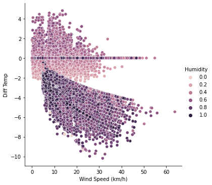

```python
plt.figure(figsize=(15, 15))
sns.relplot(hue='Humidity', y='Diff Temp', x='Wind Speed (km/h)', data=df)
```

Parece que algunos datos generan una distorsión y puede haber errores de registro, el aislamiento y limpieza de los mismos está fuera del alcance de este ejercicio, por el momento.

Procedamos a revisar qué tanto se relacionan la humedad y las dos temperaturas (real y aparente):

```python
from sklearn.linear_model import LinearRegression
from sklearn.model_selection import train_test_split
from sklearn.metrics import mean_squared_error, r2_score
```

```python
np.corrcoef(df["Humidity"].values, df["Temperature (C)"].values)
```

```
array([[ 1.        , -0.63225468],
       [-0.63225468,  1.        ]])
```

```python
X_train, X_test, y_train, y_test = train_test_split(df["Humidity"], df["Temperature (C)"], test_size=0.2, random_state=RANDOM_SEED)
```

```python
lr = LinearRegression()
```

```python
lr.fit(X_train.values.reshape(-1, 1), y_train.values.reshape(-1, 1))
```

```
LinearRegression()
```

```python
y_pred = lr.predict(X_test.values.reshape(-1, 1))
```

```python
mean_squared_error(y_test, y_pred)
```

```
55.041561179755014
```

```python
r2_score(y_test, y_pred)
```

```
0.40556262223494743
```

### Conclusiones

De los anteriores resultados podemos observar que, aunque no se tiene un score *R2* que indique una correlación fuerte entre Humedad y temperatura, sí se percibe una leve correlación entre ambas.

## Pregunta #2

¿Es posible predecir el comportamiento de ls temperatura aparente a partir de la humedad relativa?

```python
from sklearn.linear_model import LinearRegression
from sklearn.model_selection import train_test_split
from sklearn.metrics import mean_squared_error, r2_score
```

```python
np.corrcoef(df["Humidity"].values, df["Apparent Temperature (C)"].values)
```

```
array([[ 1.      , -0.602571],
       [-0.602571,  1.      ]])
```

```python
X_train, X_test, y_train, y_test = train_test_split(df["Humidity"], df["Apparent Temperature (C)"], test_size=0.2, random_state=RANDOM_SEED)
```

```python
lr = LinearRegression()
```

```python
lr.fit(X_train.values.reshape(-1, 1), y_train.values.reshape(-1, 1))
```

```
LinearRegression()
```

```python
y_pred = lr.predict(X_test.values.reshape(-1, 1))
```

```python
mean_squared_error(y_test, y_pred)
```

```
74.19147075318766
```

```python
r2_score(y_test, y_pred)
```

```
0.3587532329296208
```

## Conclusiones

Se detecta que no existe una correlación fuerte entre la humedad y los valores de temperatura real y aparente, aunque puedan tener algún comportamiento común, el valor de humedad no es suficiente para predecir confiablemente ninguna de las características de temperatura.